# B52_Quantum_State_of_a_Qubit

| Abuzer Yakaryilmaz \| April 27, 2019 (updated) |
| --- |
| This cell contains some macros. If there is a problem with displaying mathematical formulas, please run this cell to load these macros. |

$ \newcommand{\bra}[1]{\langle #1|} $ $ \newcommand{\ket}[1]{|#1\rangle} $ $ \newcommand{\braket}[2]{\langle #1|#2\rangle} $ $ \newcommand{\dot}[2]{ #1 \cdot #2} $ $ \newcommand{\biginner}[2]{\left\langle #1,#2\right\rangle} $ $ \newcommand{\mymatrix}[2]{\left( \begin{array}{#1} #2\end{array} \right)} $ $ \newcommand{\myvector}[1]{\mymatrix{c}{#1}} $ $ \newcommand{\myrvector}[1]{\mymatrix{r}{#1}} $ $ \newcommand{\mypar}[1]{\left( #1 \right)} $ $ \newcommand{\mybigpar}[1]{ \Big( #1 \Big)} $ $ \newcommand{\sqrttwo}{\frac{1}{\sqrt{2}}} $ $ \newcommand{\dsqrttwo}{\dfrac{1}{\sqrt{2}}} $ $ \newcommand{\onehalf}{\frac{1}{2}} $ $ \newcommand{\donehalf}{\dfrac{1}{2}} $ $ \newcommand{\hadamard}{ \mymatrix{rr}{ \sqrttwo & \sqrttwo \\ \sqrttwo & -\sqrttwo }} $ $ \newcommand{\vzero}{\myvector{1\\0}} $ $ \newcommand{\vone}{\myvector{0\\1}} $ $ \newcommand{\vhadamardzero}{\myvector{ \sqrttwo \\ \sqrttwo } } $ $ \newcommand{\vhadamardone}{ \myrvector{ \sqrttwo \\ -\sqrttwo } } $ $ \newcommand{\myarray}[2]{ \begin{array}{#1}#2\end{array}} $ $ \newcommand{\X}{ \mymatrix{cc}{0 & 1 \\ 1 & 0} } $ $ \newcommand{\Z}{ \mymatrix{rr}{1 & 0 \\ 0 & -1} } $ $ \newcommand{\Htwo}{ \mymatrix{rrrr}{ \frac{1}{2} & \frac{1}{2} & \frac{1}{2} & \frac{1}{2} \\ \frac{1}{2} & -\frac{1}{2} & \frac{1}{2} & -\frac{1}{2} \\ \frac{1}{2} & \frac{1}{2} & -\frac{1}{2} & -\frac{1}{2} \\ \frac{1}{2} & -\frac{1}{2} & -\frac{1}{2} & \frac{1}{2} } } $ $ \newcommand{\CNOT}{ \mymatrix{cccc}{1 & 0 & 0 & 0 \\ 0 & 1 & 0 & 0 \\ 0 & 0 & 0 & 1 \\ 0 & 0 & 1 & 0} } $ $ \newcommand{\norm}[1]{ \left\lVert #1 \right\rVert } $

## Quantum State of a Qubit

| *We use certain tools from python library "**matplotlib.pyplot**" for drawing. Check the notebook "Python: Drawing" for the list of these tools.* |
| --- |

Suppose that we have a single qubit.

Each possible (real-valued) quantum state of this qubit is a point on 2-dimensional space.

It can also be represented as a vector from origin to that point.

We draw the quantum state $ \myvector{3/5 \\ 4/5} $ and its elements.

Our predefined function "draw_qubit()" draws a figure, the origin, the axes, the unit circle, and base quantum states.  
Our predefined function "draw_quantum_state(x,y,name)" draws an arrow from (0,0) to (x,y) and associates it with name.  
We include our predefined functions with the following line of code:

```
%run qlatvia.py
```

```python
%run qlatvia.py

draw_qubit()

draw_quantum_state(3/5,4/5,"|v>")
```

[output not shown]

Now, we draw its angle with $ \ket{0} $-axis and its projections on both axes.

*For drawing the angle, we use the method "Arc" from library "matplotlib.patches".*

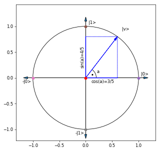

```python
%run qlatvia.py

draw_qubit()

draw_quantum_state(3/5,4/5,"|v>")

from matplotlib.pyplot import arrow, text, gca

# the projection on |0>-axis
arrow(0,0,3/5,0,color="blue",linewidth=1.5)
arrow(0,4/5,3/5,0,color="blue",linestyle='dotted')
text(0.1,-0.1,"cos(a)=3/5")

# the projection on |1>-axis
arrow(0,0,0,4/5,color="blue",linewidth=1.5)
arrow(3/5,0,0,4/5,color="blue",linestyle='dotted')
text(-0.1,0.55,"sin(a)=4/5",rotation="90")

# drawing the angle with |0>-axis
from matplotlib.patches import Arc
gca().add_patch( Arc((0,0),0.4,0.4,angle=0,theta1=0,theta2=53) )
text(0.08,0.05,'.',fontsize=30)
text(0.21,0.09,'a')
```

**Observations:**

- The angle of quantum state with state $ \ket{0} $ is $a$.
- The amplitude of state $ \ket{0} $ is $ \cos(a) = \frac{3}{5} $.
- The probability of observing state $ \ket{0} $ is $ \cos^2(a) = \frac{9}{25} $.
- The amplitude of state $ \ket{1} $ is $ \sin(a) = \frac{4}{5} $.
- The probability of observing state $ \ket{1} $ is $ \sin^2(a) = \frac{16}{25} $.

**Remarks:**

If the amplitude of $ \ket{0} $ is $ x $, then its angle with $ \ket{0} $ is $ \cos^{-1}(x) $.

Inverse cosine is denoted by "$ \arccos $", and so this angle is $ \arccos(x) $.

In python, "math.acos(x)" returns the arccos of x in radians.

A full circle refers to 360 degrees and it is equivalent to $ 2\pi $ radians.

*Do you think that a single component of a quantum state is enough to determine its angle with state $\ket{0}$?*

### Task 1

Randomly create a quantum state: $\myvector{x\\y}$.

| *You may use your code written for a task given in notebook "Quantum States".* |
| --- |

Draw your quantum state on the unit circle.

Then, determine its angle with $ \ket{0} $ by using method "math.acos(x)" in python.

Visually verify your result.

Repeat this task for a few times.

```
angle: 68.02724021884558 degrees
```

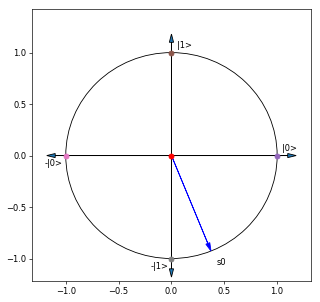

```python
%run qlatvia.py

draw_qubit()

from math import acos, pi

#
# your solution is here
#
quantum_state = random_quantum_state()
# obtain the degree with x-axis
radian = acos(quantum_state[0])
# convert radians to degree
angle = 360 * radian/(2*pi)
print("angle: " + str(angle) + " degrees")
# verify by visualizing the quantum state
draw_quantum_state(quantum_state[0],quantum_state[1],"s0")
```

click for our solution

We draw them with their elements:

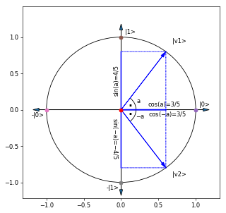

```python
%run qlatvia.py

draw_qubit()

draw_quantum_state(3/5,4/5,"|v1>")
draw_quantum_state(3/5,-4/5,"|v2>")

from matplotlib.pyplot import arrow, text, gca

# the projection on |0>-axis
arrow(0,0,3/5,0,color="blue",linewidth=1.5)
arrow(0,0,3/5,0,color="blue",linewidth=1.5)
arrow(0,4/5,3/5,0,color="blue",linestyle='dotted')
arrow(0,-4/5,3/5,0,color="blue",linestyle='dotted')
text(0.36,0.05,"cos(a)=3/5")
text(0.36,-0.09,"cos($-$a)=3/5")


# the projection on |1>-axis
arrow(0,0,0,4/5,color="blue",linewidth=1.5)
arrow(0,0,0,-4/5,color="blue",linewidth=1.5)
arrow(3/5,0,0,4/5,color="blue",linestyle='dotted')
arrow(3/5,0,0,-4/5,color="blue",linestyle='dotted')
text(-0.1,0.55,"sin(a)=4/5",rotation="90")
text(-0.14,-0.2,"sin($-$a)=$-$4/5",rotation="270")

# drawing the angle with |0>-axis
from matplotlib.patches import Arc
gca().add_patch( Arc((0,0),0.4,0.4,angle=0,theta1=0,theta2=53) )
text(0.08,0.05,'.',fontsize=30)
text(0.21,0.09,'a')
gca().add_patch( Arc((0,0),0.4,0.4,angle=0,theta1=-53,theta2=0) )
text(0.08,-0.07,'.',fontsize=30)
text(0.19,-0.12,'$-$a')
```

**Observations:**

- The angle between $ \ket{v_2} $ and $ \ket{0} $ is still $a$, but the angle of $ \ket{v_2} $ is $ -a $.
- As $ \cos(x) = \cos(-x) $, we have $ \cos(a) = \cos(-a) = \frac{3}{5} $.
- As $ \sin(x) = -\sin(-x) $, we have $ \sin(a) = \frac{4}{5} $ and $ \sin(-a) = - \frac{4}{5} $.

**Remark:** For any angle $ x $ (in radians), we have

$$ \cdots = \sin(x+4\pi) = \sin(x+2\pi) = \sin(x) = \sin(x-2\pi) = \sin(x-4\pi) = \cdots $$$$ \cdots = \cos(x+4\pi) = \cos(x+2\pi) = \cos(x) = \cos(x-2\pi) = \cos(x-4\pi) = \cdots . $$

Thus, the angle of $ \ket{v_2} $ can also be referred as $2\pi-a$.

### The angle of a quantum state

The angle of a vector (in radians) on the unit circle is the length of arc in counter-clockwise direction that starts from $ (1,0) $ and with the points representing the vector.

We execute the following code a couple of times to see different examples, where the angle is picked randomly in each run.

You can also set the value of "myangle" manually for seeing a specific angle.

```
the selected angle is 336 degrees
it is 0.933 of a full circle
its length is 0.933 x 2π = 5.862211891598554
its radian value is 5.8643062867009474
```

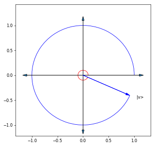

```python
# set the angle

from random import randrange
myangle = randrange(361)

################################################

from matplotlib.pyplot import figure,gca
from matplotlib.patches import Arc
from math import sin,cos,pi

# draw a figure
figure(figsize=(6,6), dpi=60)

%run qlatvia.py

draw_axes()

print("the selected angle is",myangle,"degrees")

ratio_of_arc = ((1000*myangle/360)//1)/1000

print("it is",ratio_of_arc,"of a full circle")

print("its length is",ratio_of_arc,"x 2\u03C0","=",ratio_of_arc*2*pi)

myangle_in_radian = 2*pi*(myangle/360)

print("its radian value is",myangle_in_radian)

gca().add_patch( Arc((0,0),0.2,0.2,angle=0,theta1=0,theta2=myangle,color="red") )

gca().add_patch( Arc((0,0),2,2,angle=0,theta1=0,theta2=myangle,color="blue") )

x = cos(myangle_in_radian)
y = sin(myangle_in_radian)

draw_quantum_state(x,y,"|v>")
```

### Task 2

Randomly create a quantum state, and then find its angle.

| *You may use your code written for a task given in notebook "Quantum States".* |
| --- |

Draw your quantum state on the unit circle.

Visually verify your result.

Repeat this task for a few times.

```
the selected angle is 136.71990638375763 degrees
it is 0.933 of a full circle
its length is 0.933 x 2π = 5.862211891598554
its radian value is 2.386212519414985
```

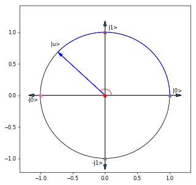

```python
%run qlatvia.py

draw_qubit()

from math import acos, pi

#
# your solution is here
#
# get the random quantum state
quantum_state = random_quantum_state()
x, y = quantum_state[0], quantum_state[1]
# obtain the degree with x-axis
radian = acos(x)
# convert radians to degree
angle = 360 * radian/(2*pi)

print("the selected angle is",angle,"degrees")

ratio_of_arc = ((1000*myangle/360)//1)/1000

print("it is",ratio_of_arc,"of a full circle")

print("its length is",ratio_of_arc,"x 2\u03C0","=",ratio_of_arc*2*pi)

angle_in_radian = 2*pi*(angle/360)

print("its radian value is",angle_in_radian)

gca().add_patch( Arc((0,0),0.2,0.2,angle=0,theta1=0,theta2=angle,color="red") )

gca().add_patch( Arc((0,0),2,2,angle=0,theta1=0,theta2=angle,color="blue") )

x = cos(angle_in_radian)
y = sin(angle_in_radian)
# draw the axes
draw_axes()
draw_quantum_state(x,y,"|u>")
```

click for our solution